# Tutorial - linear regression

# 3 Another example

```r
# install.packages("datarium")
# devtools::install_github("kassmbara/datarium")

library(datarium)
```

```r
data("marketing", package = "datarium")
marketing
```

| youtube | facebook | newspaper | sales |
| --- | --- | --- | --- |
| 276.12 | 45.36 | 83.04 | 26.52 |
| 53.40 | 47.16 | 54.12 | 12.48 |
| 20.64 | 55.08 | 83.16 | 11.16 |
| 181.80 | 49.56 | 70.20 | 22.20 |
| 216.96 | 12.96 | 70.08 | 15.48 |
| 10.44 | 58.68 | 90.00 | 8.64 |
| 69.00 | 39.36 | 28.20 | 14.16 |
| 144.24 | 23.52 | 13.92 | 15.84 |
| 10.32 | 2.52 | 1.20 | 5.76 |
| 239.76 | 3.12 | 25.44 | 12.72 |

[output cut: 190 more lines]

```r
cor(marketing)
```

```
             youtube   facebook  newspaper     sales
youtube   1.00000000 0.05480866 0.05664787 0.7822244
facebook  0.05480866 1.00000000 0.35410375 0.5762226
newspaper 0.05664787 0.35410375 1.00000000 0.2282990
sales     0.78222442 0.57622257 0.22829903 1.0000000
```

```r
marketing %<>%
  mutate(Total =  youtube + facebook + newspaper) %>%
  mutate(Prop_Newspaper = newspaper/Total) %>%
  mutate(Prop_Youtube = youtube/Total)
```

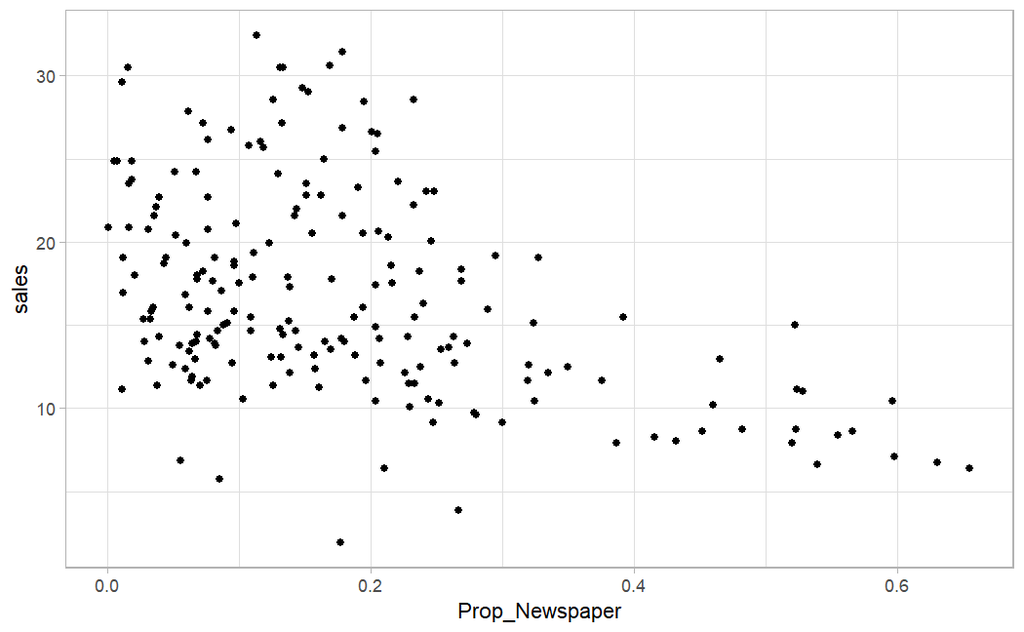

```r
ggplot(data = marketing) +
  geom_point(aes( x= Prop_Newspaper     , y = sales)) +
  theme_light()
```

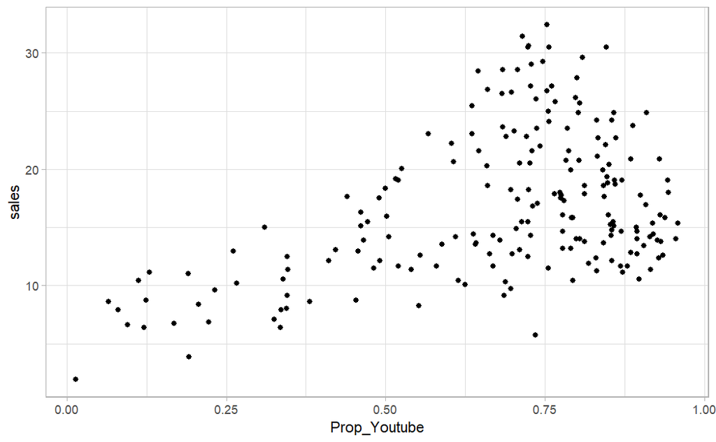

```r
ggplot(data = marketing) +
  geom_point(aes( x= Prop_Youtube, y = sales)) +
  theme_light()
```

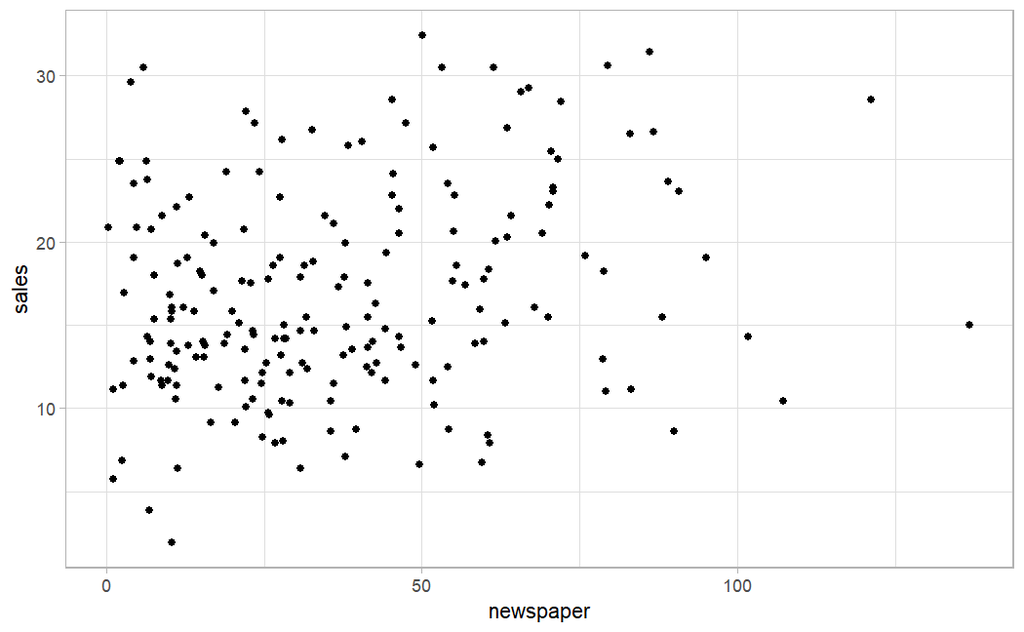

```r
ggplot(data = marketing) +
  geom_point(aes( x= newspaper     , y = sales)) +
  theme_light()
```

```r
summary(marketing)
```

```
    youtube          facebook       newspaper          sales           Total
 Min.   :  0.84   Min.   : 0.00   Min.   :  0.36   Min.   : 1.92   Min.   : 14.04
 1st Qu.: 89.25   1st Qu.:11.97   1st Qu.: 15.30   1st Qu.:12.45   1st Qu.:148.26
 Median :179.70   Median :27.48   Median : 30.90   Median :15.48   Median :248.82
 Mean   :176.45   Mean   :27.92   Mean   : 36.66   Mean   :16.83   Mean   :241.03
 3rd Qu.:262.59   3rd Qu.:43.83   3rd Qu.: 54.12   3rd Qu.:20.88   3rd Qu.:337.35
 Max.   :355.68   Max.   :59.52   Max.   :136.80   Max.   :32.40   Max.   :520.32
 Prop_Newspaper      Prop_Youtube
 Min.   :0.001049   Min.   :0.01429
 1st Qu.:0.074894   1st Qu.:0.58580
 Median :0.144936   Median :0.73248
 Mean   :0.178757   Mean   :0.67809
 3rd Qu.:0.234432   3rd Qu.:0.84160
 Max.   :0.654732   Max.   :0.95846
```

```r
Model_Sales_Marketing <- lm("sales ~ youtube + facebook + newspaper",
                            data = marketing)
```

```r
summary(Model_Sales_Marketing)
```

```
Call:
lm(formula = "sales ~ youtube + facebook + newspaper", data = marketing)

Residuals:
     Min       1Q   Median       3Q      Max
-10.5932  -1.0690   0.2902   1.4272   3.3951

Coefficients:
             Estimate Std. Error t value Pr(>|t|)
(Intercept)  3.526667   0.374290   9.422   <2e-16 ***
youtube      0.045765   0.001395  32.809   <2e-16 ***
facebook     0.188530   0.008611  21.893   <2e-16 ***
newspaper   -0.001037   0.005871  -0.177     0.86
---
Signif. codes:  0 ‘***’ 0.001 ‘**’ 0.01 ‘*’ 0.05 ‘.’ 0.1 ‘ ’ 1

Residual standard error: 2.023 on 196 degrees of freedom
Multiple R-squared:  0.8972,    Adjusted R-squared:  0.8956
F-statistic: 570.3 on 3 and 196 DF,  p-value: < 2.2e-16
```

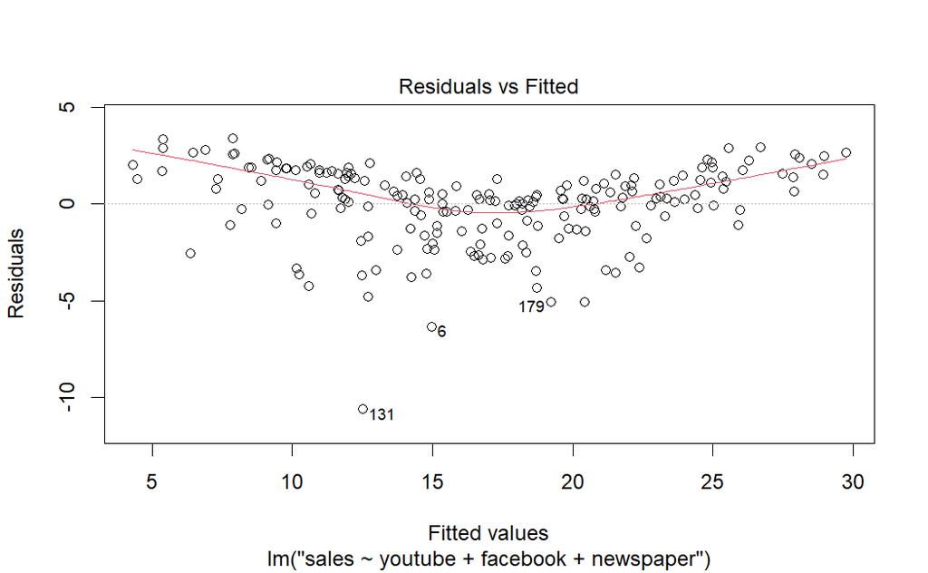

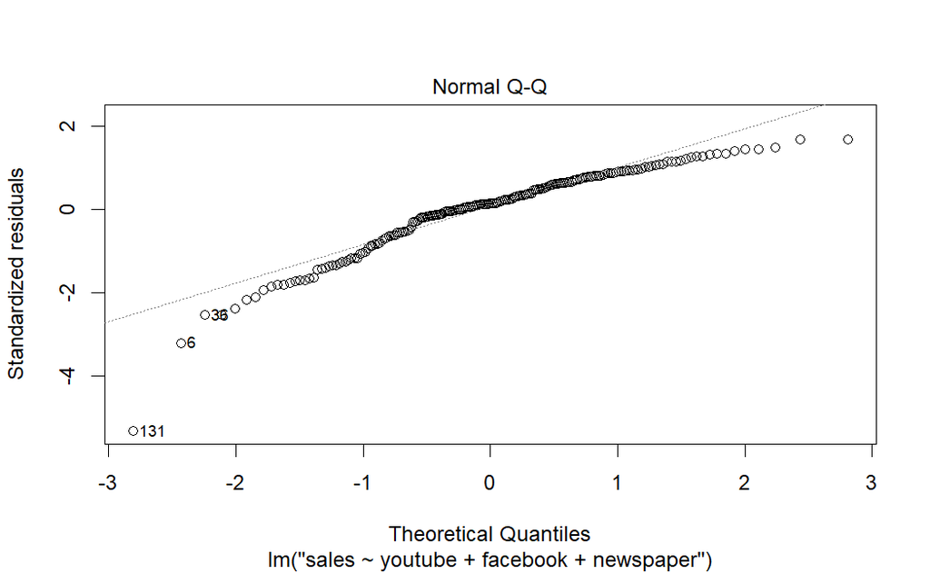

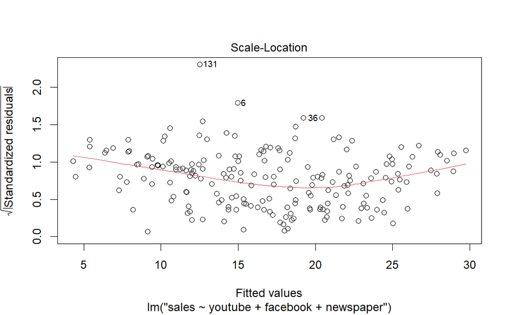

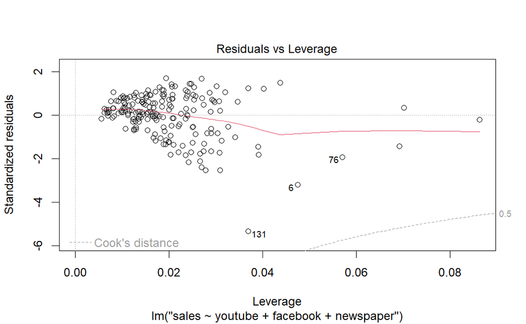

```r
plot(Model_Sales_Marketing)
```

```r
summary(lm("sales ~ youtube + facebook + newspaper", data = marketing))
```

```
Call:
lm(formula = "sales ~ youtube + facebook + newspaper", data = marketing)

Residuals:
     Min       1Q   Median       3Q      Max
-10.5932  -1.0690   0.2902   1.4272   3.3951

Coefficients:
             Estimate Std. Error t value Pr(>|t|)
(Intercept)  3.526667   0.374290   9.422   <2e-16 ***
youtube      0.045765   0.001395  32.809   <2e-16 ***
facebook     0.188530   0.008611  21.893   <2e-16 ***
newspaper   -0.001037   0.005871  -0.177     0.86
---
Signif. codes:  0 ‘***’ 0.001 ‘**’ 0.01 ‘*’ 0.05 ‘.’ 0.1 ‘ ’ 1

Residual standard error: 2.023 on 196 degrees of freedom
Multiple R-squared:  0.8972,    Adjusted R-squared:  0.8956
F-statistic: 570.3 on 3 and 196 DF,  p-value: < 2.2e-16
```

```r
summary(lm("sales ~ youtube + facebook", data = marketing))
```

```
Call:
lm(formula = "sales ~ youtube + facebook", data = marketing)

Residuals:
     Min       1Q   Median       3Q      Max
-10.5572  -1.0502   0.2906   1.4049   3.3994

Coefficients:
            Estimate Std. Error t value Pr(>|t|)
(Intercept)  3.50532    0.35339   9.919   <2e-16 ***
youtube      0.04575    0.00139  32.909   <2e-16 ***
facebook     0.18799    0.00804  23.382   <2e-16 ***
---
Signif. codes:  0 ‘***’ 0.001 ‘**’ 0.01 ‘*’ 0.05 ‘.’ 0.1 ‘ ’ 1

Residual standard error: 2.018 on 197 degrees of freedom
Multiple R-squared:  0.8972,    Adjusted R-squared:  0.8962
F-statistic: 859.6 on 2 and 197 DF,  p-value: < 2.2e-16
```

```r
summary(lm("sales ~ youtube", data = marketing))
```

```
Call:
lm(formula = "sales ~ youtube", data = marketing)

Residuals:
     Min       1Q   Median       3Q      Max
-10.0632  -2.3454  -0.2295   2.4805   8.6548

Coefficients:
            Estimate Std. Error t value Pr(>|t|)
(Intercept) 8.439112   0.549412   15.36   <2e-16 ***
youtube     0.047537   0.002691   17.67   <2e-16 ***
---
Signif. codes:  0 ‘***’ 0.001 ‘**’ 0.01 ‘*’ 0.05 ‘.’ 0.1 ‘ ’ 1

Residual standard error: 3.91 on 198 degrees of freedom
Multiple R-squared:  0.6119,    Adjusted R-squared:  0.6099
F-statistic: 312.1 on 1 and 198 DF,  p-value: < 2.2e-16
```

```r
summary(lm("sales ~  facebook + newspaper", data = marketing))
```

```
Call:
lm(formula = "sales ~  facebook + newspaper", data = marketing)

Residuals:
     Min       1Q   Median       3Q      Max
-18.6347  -2.5739   0.8778   3.3188   9.5701

Coefficients:
             Estimate Std. Error t value Pr(>|t|)
(Intercept) 11.026705   0.753206  14.640   <2e-16 ***
facebook     0.199045   0.021870   9.101   <2e-16 ***
newspaper    0.006644   0.014909   0.446    0.656
---
Signif. codes:  0 ‘***’ 0.001 ‘**’ 0.01 ‘*’ 0.05 ‘.’ 0.1 ‘ ’ 1

Residual standard error: 5.14 on 197 degrees of freedom
Multiple R-squared:  0.3327,    Adjusted R-squared:  0.3259
F-statistic: 49.11 on 2 and 197 DF,  p-value: < 2.2e-16
```

```r
summary(lm("sales ~  newspaper", data = marketing))
```

```
Call:
lm(formula = "sales ~  newspaper", data = marketing)

Residuals:
    Min      1Q  Median      3Q     Max
-13.473  -4.065  -1.007   4.207  15.330

Coefficients:
            Estimate Std. Error t value Pr(>|t|)
(Intercept) 14.82169    0.74570   19.88  < 2e-16 ***
newspaper    0.05469    0.01658    3.30  0.00115 **
---
Signif. codes:  0 ‘***’ 0.001 ‘**’ 0.01 ‘*’ 0.05 ‘.’ 0.1 ‘ ’ 1

Residual standard error: 6.111 on 198 degrees of freedom
Multiple R-squared:  0.05212,   Adjusted R-squared:  0.04733
F-statistic: 10.89 on 1 and 198 DF,  p-value: 0.001148
```

# 4 A note on categorical variables

```r
data("Salaries", package = "carData")
```

```r
Salaries
```

| rank | discipline | yrs.since.phd | yrs.service | sex | salary |
| --- | --- | --- | --- | --- | --- |
| Prof | B | 19 | 18 | Male | 139750 |
| Prof | B | 20 | 16 | Male | 173200 |
| AsstProf | B | 4 | 3 | Male | 79750 |
| Prof | B | 45 | 39 | Male | 115000 |
| Prof | B | 40 | 41 | Male | 141500 |
| AssocProf | B | 6 | 6 | Male | 97000 |
| Prof | B | 30 | 23 | Male | 175000 |
| Prof | B | 45 | 45 | Male | 147765 |
| Prof | B | 21 | 20 | Male | 119250 |
| Prof | B | 18 | 18 | Female | 129000 |

[output cut: 387 more lines]

```r
Model_1 <- lm("salary ~ sex", data = Salaries)
summary(Model_1)
```

```
Call:
lm(formula = "salary ~ sex", data = Salaries)

Residuals:
   Min     1Q Median     3Q    Max
-57290 -23502  -6828  19710 116455

Coefficients:
            Estimate Std. Error t value Pr(>|t|)
(Intercept)   101002       4809  21.001  < 2e-16 ***
sexMale        14088       5065   2.782  0.00567 **
---
Signif. codes:  0 ‘***’ 0.001 ‘**’ 0.01 ‘*’ 0.05 ‘.’ 0.1 ‘ ’ 1

Residual standard error: 30030 on 395 degrees of freedom
Multiple R-squared:  0.01921,   Adjusted R-squared:  0.01673
F-statistic: 7.738 on 1 and 395 DF,  p-value: 0.005667
```

```r
class(Salaries$sex)
```

```
[1] "factor"
```

```r
levels(Salaries$sex)
```

```
[1] "Female" "Male"
```

```r
Salaries %<>%
  mutate(Sex_Character = sex) %>%
  mutate(Sex_Male = if_else(Sex_Character == "Male", 1, 0),
         Sex_Female = if_else(Sex_Character == "Female", 1, 0))


# Salario = B0 +B_M*Male
```

```r
Salaries
```

| rank | discipline | yrs.since.phd | yrs.service | sex | salary | Sex_Character | Sex_Male | Sex_Female |
| --- | --- | --- | --- | --- | --- | --- | --- | --- |
| Prof | B | 19 | 18 | Male | 139750 | Male | 1 | 0 |
| Prof | B | 20 | 16 | Male | 173200 | Male | 1 | 0 |
| AsstProf | B | 4 | 3 | Male | 79750 | Male | 1 | 0 |
| Prof | B | 45 | 39 | Male | 115000 | Male | 1 | 0 |
| Prof | B | 40 | 41 | Male | 141500 | Male | 1 | 0 |
| AssocProf | B | 6 | 6 | Male | 97000 | Male | 1 | 0 |
| Prof | B | 30 | 23 | Male | 175000 | Male | 1 | 0 |
| Prof | B | 45 | 45 | Male | 147765 | Male | 1 | 0 |
| Prof | B | 21 | 20 | Male | 119250 | Male | 1 | 0 |
| Prof | B | 18 | 18 | Female | 129000 | Female | 0 | 1 |

[output cut: 387 more lines]

```r
Model_2 <- lm("salary ~ Sex_Male", data = Salaries)
summary(Model_2)
```

```
Call:
lm(formula = "salary ~ Sex_Male", data = Salaries)

Residuals:
   Min     1Q Median     3Q    Max
-57290 -23502  -6828  19710 116455

Coefficients:
            Estimate Std. Error t value Pr(>|t|)
(Intercept)   101002       4809  21.001  < 2e-16 ***
Sex_Male       14088       5065   2.782  0.00567 **
---
Signif. codes:  0 ‘***’ 0.001 ‘**’ 0.01 ‘*’ 0.05 ‘.’ 0.1 ‘ ’ 1

Residual standard error: 30030 on 395 degrees of freedom
Multiple R-squared:  0.01921,   Adjusted R-squared:  0.01673
F-statistic: 7.738 on 1 and 395 DF,  p-value: 0.005667
```

```r
Model_3 <- lm("salary ~ Sex_Female", data = Salaries)
summary(Model_3)
```

```
Call:
lm(formula = "salary ~ Sex_Female", data = Salaries)

Residuals:
   Min     1Q Median     3Q    Max
-57290 -23502  -6828  19710 116455

Coefficients:
            Estimate Std. Error t value Pr(>|t|)
(Intercept)   115090       1587  72.503  < 2e-16 ***
Sex_Female    -14088       5065  -2.782  0.00567 **
---
Signif. codes:  0 ‘***’ 0.001 ‘**’ 0.01 ‘*’ 0.05 ‘.’ 0.1 ‘ ’ 1

Residual standard error: 30030 on 395 degrees of freedom
Multiple R-squared:  0.01921,   Adjusted R-squared:  0.01673
F-statistic: 7.738 on 1 and 395 DF,  p-value: 0.005667
```

```r
Salaries %>% group_by(sex) %>% summarise(MeanPerSex = mean(salary),
                                         PeopleInSurvey = n())
```

| sex | MeanPerSex | PeopleInSurvey |
| --- | --- | --- |
| Female | 101002.4 | 39 |
| Male | 115090.4 | 358 |

```r
101002.4 - 115090.4
```

```
[1] -14088
```

# 5 A note on interactions

```r
names(Salaries)
```

```
[1] "rank"          "discipline"    "yrs.since.phd" "yrs.service"   "sex"           "salary"
[7] "Sex_Character" "Sex_Male"      "Sex_Female"
```

```r
Model_1 <- Salaries %>% lm("salary ~ yrs.service + discipline", data = .)
summary(Model_1)
```

```
Call:
lm(formula = "salary ~ yrs.service + discipline", data = .)

Residuals:
   Min     1Q Median     3Q    Max
-77537 -19699  -5135  15631 106625

Coefficients:
            Estimate Std. Error t value Pr(>|t|)
(Intercept)  91335.8     3005.4  30.391  < 2e-16 ***
yrs.service    862.8      109.2   7.904 2.73e-14 ***
disciplineB  13184.0     2846.8   4.631 4.95e-06 ***
---
Signif. codes:  0 ‘***’ 0.001 ‘**’ 0.01 ‘*’ 0.05 ‘.’ 0.1 ‘ ’ 1

Residual standard error: 27870 on 394 degrees of freedom
Multiple R-squared:  0.1579,    Adjusted R-squared:  0.1536
F-statistic: 36.94 on 2 and 394 DF,  p-value: 1.983e-15
```

```r
class(Salaries$discipline)
```

```
[1] "factor"
```

```r
levels(Salaries$discipline)
```

```
[1] "A" "B"
```

```r
Salaries$discipline <- as.character(Salaries$discipline)

Salaries$discipline <- factor(Salaries$discipline, levels = c("B", "A"))
```

```r
Salaries %>% group_by(discipline) %>% summarize(Meam =mean(salary), N = n())
```

| discipline | Meam | N |
| --- | --- | --- |
| B | 118028.7 | 216 |
| A | 108548.4 | 181 |

```r
names(Salaries)
```

```
[1] "rank"          "discipline"    "yrs.since.phd" "yrs.service"   "sex"           "salary"
[7] "Sex_Character" "Sex_Male"      "Sex_Female"
```

```r
names(Salaries)[4] <- "Years_Service"
```

```r
names(Salaries)
```

```
[1] "rank"          "discipline"    "yrs.since.phd" "Years_Service" "sex"           "salary"
[7] "Sex_Character" "Sex_Male"      "Sex_Female"
```

```r
Salaries %<>%
  mutate(Sociology = if_else(discipline == "A", 1, 0),
         Engineer = if_else(discipline == "B", 1, 0)) %>%
  mutate(Interac_YrServices_Engineer = Years_Service*Engineer) %>%
  mutate(Interac_YrServices_Sociology = Years_Service*Sociology)
```

```r
Equation_0 <- "salary ~ Years_Service + discipline + Years_Service*discipline"

Equation_1 <- "salary ~ Years_Service + Sociology + Years_Service*Sociology"

Equation_2 <- "salary ~ Years_Service + Sociology + Interac_YrServices_Sociology"
```

```r
summary(lm(Equation_0, data = Salaries))
```

```
Call:
lm(formula = Equation_0, data = Salaries)

Residuals:
   Min     1Q Median     3Q    Max
-86326 -19779  -4999  16091 102274

Coefficients:
                          Estimate Std. Error t value Pr(>|t|)
(Intercept)                98895.4     3068.4  32.230  < 2e-16 ***
Years_Service               1222.0      155.2   7.874 3.37e-14 ***
disciplineA                 -857.4     4750.7  -0.180  0.85687
Years_Service:disciplineA   -695.2      215.9  -3.220  0.00139 **
---
Signif. codes:  0 ‘***’ 0.001 ‘**’ 0.01 ‘*’ 0.05 ‘.’ 0.1 ‘ ’ 1

Residual standard error: 27540 on 393 degrees of freedom
Multiple R-squared:  0.1795,    Adjusted R-squared:  0.1733
F-statistic: 28.67 on 3 and 393 DF,  p-value: < 2.2e-16
```

```r
summary(lm(Equation_1, data = Salaries))
```

```
Call:
lm(formula = Equation_1, data = Salaries)

Residuals:
   Min     1Q Median     3Q    Max
-86326 -19779  -4999  16091 102274

Coefficients:
                        Estimate Std. Error t value Pr(>|t|)
(Intercept)              98895.4     3068.4  32.230  < 2e-16 ***
Years_Service             1222.0      155.2   7.874 3.37e-14 ***
Sociology                 -857.4     4750.7  -0.180  0.85687
Years_Service:Sociology   -695.2      215.9  -3.220  0.00139 **
---
Signif. codes:  0 ‘***’ 0.001 ‘**’ 0.01 ‘*’ 0.05 ‘.’ 0.1 ‘ ’ 1

Residual standard error: 27540 on 393 degrees of freedom
Multiple R-squared:  0.1795,    Adjusted R-squared:  0.1733
F-statistic: 28.67 on 3 and 393 DF,  p-value: < 2.2e-16
```

```r
summary(lm(Equation_2, data = Salaries))
```

```
Call:
lm(formula = Equation_2, data = Salaries)

Residuals:
   Min     1Q Median     3Q    Max
-86326 -19779  -4999  16091 102274

Coefficients:
                             Estimate Std. Error t value Pr(>|t|)
(Intercept)                   98895.4     3068.4  32.230  < 2e-16 ***
Years_Service                  1222.0      155.2   7.874 3.37e-14 ***
Sociology                      -857.4     4750.7  -0.180  0.85687
Interac_YrServices_Sociology   -695.2      215.9  -3.220  0.00139 **
---
Signif. codes:  0 ‘***’ 0.001 ‘**’ 0.01 ‘*’ 0.05 ‘.’ 0.1 ‘ ’ 1

Residual standard error: 27540 on 393 degrees of freedom
Multiple R-squared:  0.1795,    Adjusted R-squared:  0.1733
F-statistic: 28.67 on 3 and 393 DF,  p-value: < 2.2e-16
```

```r
names(Salaries)
```

```
 [1] "rank"                         "discipline"                   "yrs.since.phd"
 [4] "Years_Service"                "sex"                          "salary"
 [7] "Sex_Character"                "Sex_Male"                     "Sex_Female"
[10] "Sociology"                    "Engineer"                     "Interac_YrServices_Engineer"
[13] "Interac_YrServices_Sociology"
```

```r
Equation_1 <- "salary ~ Years_Service + sex + discipline + sex*discipline"
Equation_2 <- "salary ~ Years_Service + Sex_Male + Sociology + Sex_Male*Sociology"

Equation_3 <- "salary ~ Years_Service + Sex_Male + Engineer + Sex_Male*Engineer"
```

```r
summary(lm(Equation_1, data = Salaries))
```

```
Call:
lm(formula = Equation_1, data = Salaries)

Residuals:
   Min     1Q Median     3Q    Max
-77749 -19940  -5111  16007 104763

Coefficients:
                    Estimate Std. Error t value Pr(>|t|)
(Intercept)         101606.3     6198.6  16.392  < 2e-16 ***
Years_Service          825.3      110.4   7.476 5.06e-13 ***
sexMale               3877.7     6400.1   0.606   0.5449
disciplineA         -21986.2     8925.0  -2.463   0.0142 *
sexMale:disciplineA   9962.5     9415.8   1.058   0.2907
---
Signif. codes:  0 ‘***’ 0.001 ‘**’ 0.01 ‘*’ 0.05 ‘.’ 0.1 ‘ ’ 1

Residual standard error: 27790 on 392 degrees of freedom
Multiple R-squared:  0.167, Adjusted R-squared:  0.1585
F-statistic: 19.64 on 4 and 392 DF,  p-value: 9.487e-15
```

```r
summary(lm(Equation_2, data = Salaries))
```

```
Call:
lm(formula = Equation_2, data = Salaries)

Residuals:
   Min     1Q Median     3Q    Max
-77749 -19940  -5111  16007 104763

Coefficients:
                   Estimate Std. Error t value Pr(>|t|)
(Intercept)        101606.3     6198.6  16.392  < 2e-16 ***
Years_Service         825.3      110.4   7.476 5.06e-13 ***
Sex_Male             3877.7     6400.1   0.606   0.5449
Sociology          -21986.2     8925.0  -2.463   0.0142 *
Sex_Male:Sociology   9962.5     9415.8   1.058   0.2907
---
Signif. codes:  0 ‘***’ 0.001 ‘**’ 0.01 ‘*’ 0.05 ‘.’ 0.1 ‘ ’ 1

Residual standard error: 27790 on 392 degrees of freedom
Multiple R-squared:  0.167, Adjusted R-squared:  0.1585
F-statistic: 19.64 on 4 and 392 DF,  p-value: 9.487e-15
```

```r
summary(lm(Equation_3, data = Salaries))
```

```
Call:
lm(formula = Equation_3, data = Salaries)

Residuals:
   Min     1Q Median     3Q    Max
-77749 -19940  -5111  16007 104763

Coefficients:
                  Estimate Std. Error t value Pr(>|t|)
(Intercept)        79620.1     6669.9  11.937  < 2e-16 ***
Years_Service        825.3      110.4   7.476 5.06e-13 ***
Sex_Male           13840.2     6979.6   1.983   0.0481 *
Engineer           21986.2     8925.0   2.463   0.0142 *
Sex_Male:Engineer  -9962.5     9415.8  -1.058   0.2907
---
Signif. codes:  0 ‘***’ 0.001 ‘**’ 0.01 ‘*’ 0.05 ‘.’ 0.1 ‘ ’ 1

Residual standard error: 27790 on 392 degrees of freedom
Multiple R-squared:  0.167, Adjusted R-squared:  0.1585
F-statistic: 19.64 on 4 and 392 DF,  p-value: 9.487e-15
```

# 6 A note on transformations

[From this resource](https://data.library.virginia.edu/interpreting-log-transformations-in-a-linear-model/):

- **“Only the dependent/response variable is log-transformed.** Exponentiate the coefficient, subtract one from this number, and multiply by 100. This gives the percent increase (or decrease) in the response for every one-unit increase in the independent variable. Example: the coefficient is 0.198. (exp(0.198) – 1) * 100 = 21.9. For every one-unit increase in the independent variable, our dependent variable increases by about 22%.
- **Only independent/predictor variable(s) is log-transformed.** Divide the coefficient by 100. This tells us that a 1% increase in the independent variable increases (or decreases) the dependent variable by (coefficient/100) units. Example: the coefficient is 0.198. 0.198/100 = 0.00198. For every 1% increase in the independent variable, our dependent variable increases by about 0.002. For x percent increase, multiply the coefficient by log(1.x). Example: For every 10% increase in the independent variable, our dependent variable increases by about 0.198 * log(1.10) = 0.02.
- **Both dependent/response variable and independent/predictor variable(s) are log-transformed.** Interpret the coefficient as the percent increase in the dependent variable for every 1% increase in the independent variable. Example: the coefficient is 0.198. For every 1% increase in the independent variable, our dependent variable increases by about 0.20%. For x percent increase, calculate 1.x to the power of the coefficient, subtract 1, and multiply by 100. Example: For every 20% increase in the independent variable, our dependent variable increases by about (1.20 0.198 – 1) * 100 = 3.7 percent.”

# 7 A note on “Marginals”

Marginal effects refer to the change in the predicted value of the dependent variable that results from a one-unit change in one of the independent variables, while holding all other independent variables constant.

Think of it as the specific slope on each point in the curve.

We could:

- Caclulate the marginal effect for each individual
- Calculate the marginal effect of a set of individuals
- Calculate **the Average Marginal Effect AME**
- Calculate the **Marginal Effect on the Mean MEM**

mfx::logitmfx() mfx::probitmfx()

margins::margins()